166932 — Zahid Mehdi

# **Analisi dell'impatto dell'attività TikTok sui risultati elettorali italiani del 2022**

24/06/2025 — Università degli Studi di Udine

## Il progetto in breve

*Data Science Project - Mehdi Zahid - UNIUD 2025*

[figure not shown]

## Ispirazione e metriche analizzate

Questo progetto analizza l'engagement dei politici italiani su TikTok durante le elezioni politiche del 2022. L'obiettivo è valutare il potenziale predittivo delle metriche social rispetto ai risultati elettorali ufficiali.

### Ispirazione

Lo studio è stato ispirato da casi reali di **microtargeting politico tramite social media**, in particolare lo *scandalo Cambridge Analytica* durante la campagna di **Donald Trump (2016)**. L'obiettivo era indagare se anche in Italia esistano segnali di relazione tra **attività social** e **performance elettorale**.

### Metriche TikTok analizzate

- Numero di post
- Visualizzazioni totali
- Likes ricevuti
- Commenti generati
- Condivisioni ottenute

## Origine dei Dati Utilizzati

### Dati TikTok & Attività Social

- Basati sul dataset **ITA-ELECTION-2022**: raccolta multi-piattaforma di conversazioni social sulle elezioni italiane 2022
- Fonte: github.com/frapierri/ita-election-2022
- Riferimento accademico: Pierri et al. (CIKM 2023), DOI: 10.1145/3583780.3615121
- Metadati TikTok raccolti tramite scraping e annotazioni manuali, in particolare: `Facebook_Tiktok_metadata.csv`

### Dati Elettorali Ufficiali

- Risultati delle **Elezioni Politiche 2022** per la Camera dei Deputati
- Dati pubblicati da [Eligendo – Ministero dell’Interno](https://elezioni.interno.gov.it)
- Rielaborati e messi a disposizione dal progetto [onData](https://ondata.it)
- Dataset: Politiche2022_Scrutini_Camera_Italia.csv

Per correttezza: “Dati elettorali da un progetto di [onData](https://github.com/ondata/elezioni-politiche-2022)”

## **Cosa vorrei scoprire?**

1. Come si distribuiscono le metriche TikTok durante le elezioni politiche italiane
2. Chi sono i **Top Performer** su TikTok tra i politici
3. Quale metrica TikTok è **più predittiva dei voti** reali
4. Se è possibile **prevedere in anticipo** il risultato elettorale usando TikTok

*Domande guida del progetto*

## Filtraggio Dataset TikTok Elections 2022

| Categoria | Valore |
| --- | --- |
| Video Totali Analizzati | 1,744 |
| Video Utilizzabili (Finale) | **220** (12.6%) |
| Video Scartati (Fuzzy Matching) | 1,524 (87.4%) |
| **Efficienza Pipeline** | **12.6%** |

*Pipeline di Fuzzy Matching → Politici riconosciuti correttamente*

## Filtraggio Dataset TikTok Elections 2022

### Perché il dataset finale è così ridotto?

La **maggior parte dei video (87.4%)** non hanno match validi, dovuta a:

- Username TikTok spesso diversi dai nomi reali
- Presenza di account non verificati
- Politici non presenti nel database elettorale
- Variazioni nella scrittura dei nomi

*Pipeline di Fuzzy Matching → Politici riconosciuti correttamente*

## **1) Come sono distribuite le variabili TikTok ed elettorali?**

Analisi delle **curve di densità (KDE)** per comprendere la forma e la simmetria delle principali variabili quantitative:

- **Totale voti** ricevuti da ciascun partito
- **Numero di post TikTok** pubblicati dai partiti
- **Visualizzazioni totali** su TikTok *(in scala logaritmica)*
- **Engagement complessivo**: somma di like, commenti e condivisioni *(in scala logaritmica)*

*Distribuzioni KDE per identificare skew, outlier e tendenze*

### **1) Come sono distribuite le variabili TikTok ed elettorali?**

#### **Le 4 curve di densità (KDE)**

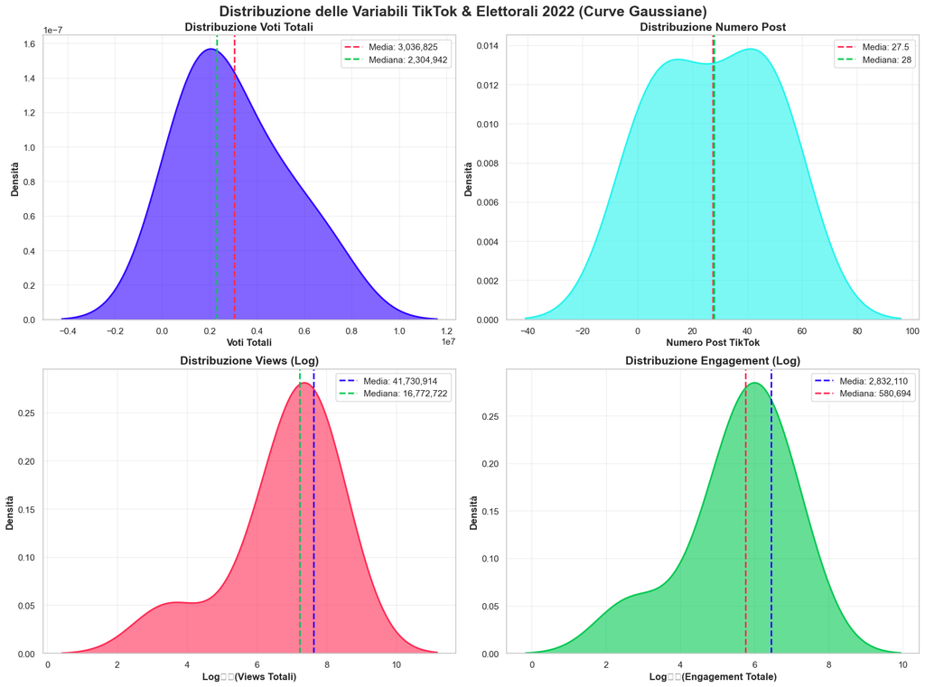

## **2) Top Performer TikTok Elections 2022**

Analisi delle performance su quattro metriche chiave per identificare i partiti più efficaci su TikTok:

- **Numero di Post TikTok:** chi ha pubblicato di più
- **Visualizzazioni Totali:** chi ha generato più attenzione
- **Engagement Totale:** chi ha stimolato più interazioni (like, commenti, condivisioni)
- **Voti Elettorali:** chi ha convertito meglio la visibilità in consenso

Per ogni metrica viene mostrata la **top 8 dei partiti** più performanti. Il formato abbreviato (`K`, `M`) facilita la lettura dei volumi.

### **2) Top Performer TikTok Elections 2022?**

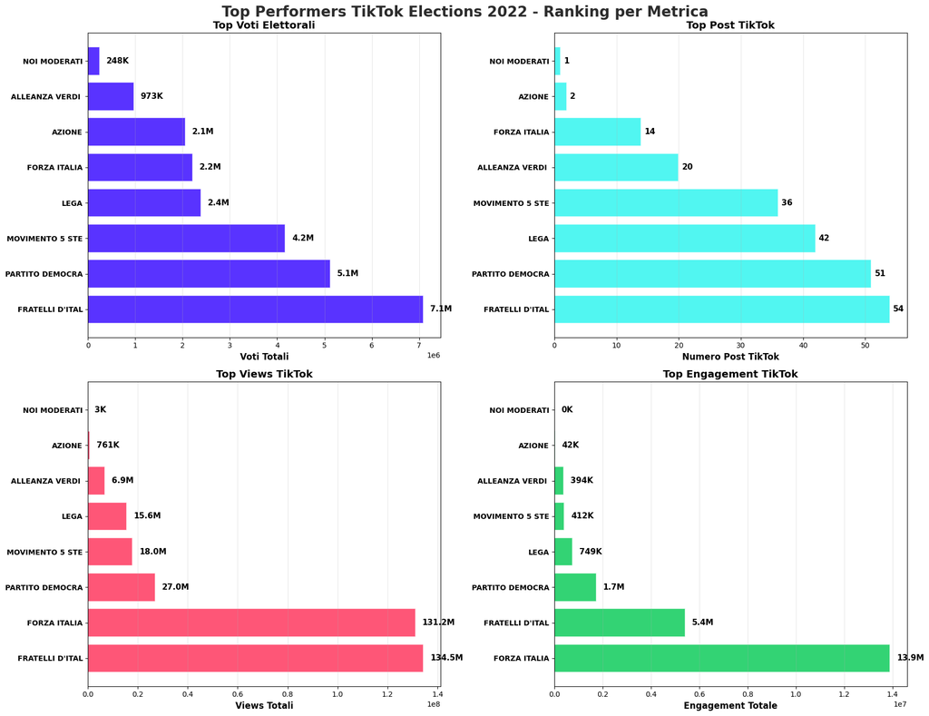

## **3) Quale metrica TikTok è più predittiva dei voti?**

Come arrivare al risultato:

- Confronto delle **correlazioni** tra ciascuna metrica TikTok e i voti ricevuti
- Utilizzo di tre metodi: **Pearson**, **Spearman** e **Kendall**
- Verifica della **significatività statistica** tramite i p-value
- Identificazione della metrica con il **r più alto** e **p < 0.05**

## **3) Quale metrica TikTok è più predittiva dei voti?**

#### **Coefficienti di correlazione**

## Analisi Correlazioni Multimetodo

| Variabile | Pearson | Spearman | Kendall | P-Pearson | P-Spearman | P-Kendall |
| --- | --- | --- | --- | --- | --- | --- |
| Numero Post | 0.839 | 0.905 | 0.786 | 0.009 | 0.002 | 0.006 |
| Views Totali | 0.541 | 0.833 | 0.714 | 0.166 | 0.010 | 0.014 |
| Engagement Totale | 0.174 | 0.714 | 0.571 | 0.680 | 0.047 | 0.061 |

Confronto tra coefficienti di correlazione per ogni metrica TikTok

## **3) Quale metrica TikTok è più predittiva dei voti?**

#### **Coefficienti di correlazione**

### Quale metrica TikTok è più predittiva dei voti?

Tra tutte le metriche analizzate, il **numero di post TikTok** mostra:

- La **correlazione più elevata** con i voti
- Valori **significativi per tutti i test** (p < 0.01)

Views ed Engagement mostrano buoni valori ma con significatività più debole.

Confronto tra coefficienti di correlazione per ogni metrica TikTok

## **4) È possibile scoprire in anticipo il risultato elettorale?**

Come arrivare al risultato:

- Analisi delle principali metriche TikTok pubbliche (**post**, **views**, **engagement**)
- Costruzione di **modelli predittivi** con regressione lineare
- Confronto tra **metodi di correlazione** (Pearson, Spearman, Kendall)
- Valutazione delle **performance predittive** (R², MAE, RMSE)

### **4) È possibile scoprire in anticipo il risultato elettorale?**

#### **Retta di regressione**

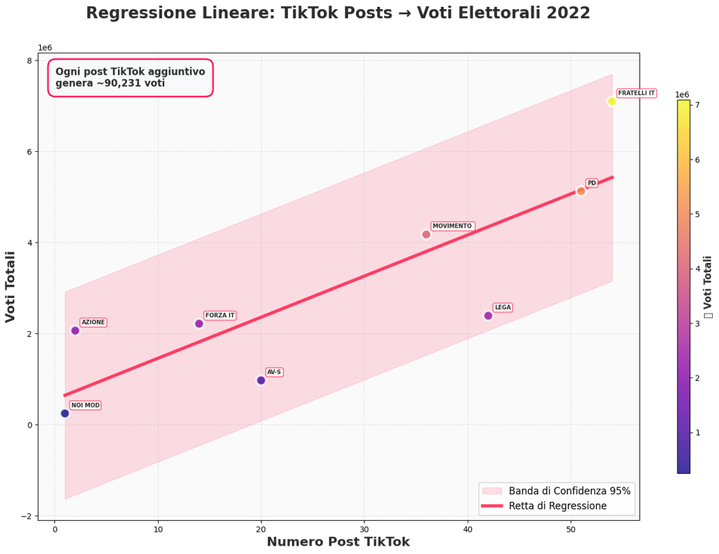

## Metriche Principali del Modello

| Metrica | Valore |
| --- | --- |
| R² (Varianza spiegata) | 0.703 → 70.3% |
| MAE (Errore Medio Assoluto) | 941,922 voti (31.0%) |
| RMSE (Errore Quadratico Medio) | 1,158,744 voti (38.2%) |

*Valutazione delle prestazioni del modello di regressione lineare*

## Metriche Principali del Modello

### Quanto è affidabile il modello?

- Spiega circa **70% della varianza** nei voti totali
- Errore medio assoluto di **~941k voti**
- RMSE più alto (1.1M) penalizza gli errori maggiori

**Conclusione:** modello buono. Adatto a stime generali, meno a previsioni precise per partiti minori.

*Valutazione delle prestazioni del modello di regressione lineare*

## **Conclusioni**

*Data Science Project - Mehdi Zahid - UNIUD 2025*